# Results Notebook

# 1 Overview

## 1.2 Randomization check

A preliminary randomization check was conducted. The check revealed no systematic differences between the three conditions in gender, age, political position, and nationality (all *p*’s > .05).

Table 1.1: Randomisation check

| Item | Dynamic | Static | No norm | Significance test |
| --- | --- | --- | --- | --- |
| Age (years) | 37.34 $\pm$ 14.22 | 37.90 $\pm$ 12.97 | 36.40 $\pm$ 13.55 | $F(2, 843) = 0.89$, $\mathit{MSE} = 184.49$, $p = .409$ |
| Gender (%) | 1 (39.49%) 2 (60.14%) 3 (0.36%) | 1 (41.9%) 2 (58.1%) | 1 (48.25%) 2 (51.05%) 3 (0.7%) | $\chi^2(4, n = 846) = 6.92$, $p = .140$ |
| Political position | 3.47 $\pm$ 1.22 | 3.54 $\pm$ 1.26 | 3.45 $\pm$ 1.26 | $F(2, 843) = 0.39$, $\mathit{MSE} = 1.55$, $p = .679$ |
| Nationality (%) | 1 (84.06%) 2 (3.62%) 3 (9.78%) 4 (0.72%) NA (1.81%) | 1 (80.99%) 2 (5.28%) 3 (8.45%) 4 (1.41%) NA (3.87%) | 1 (80.77%) 2 (5.94%) 3 (8.74%) 4 (1.75%) NA (2.8%) | $\chi^2(6, n = 846) = 3.23$, $p = .779$ |

## 1.3 Correlations

Table 1.2: Means, Standard Deviations, Reliabilities, and Inter-Correlations Among Study Measures

Alpha

M

SD

1

2

3

4

5

6

Interest

3.58

1.82

Attitude

0.90

4.64

1.29

.80**

Intention

0.98

4.22

1.80

.83**

.82**

Expectation

0.99

3.93

1.75

.80**

.80**

.92**

Intent/expectation composite

4.08

1.74

.83**

.83**

.98**

.98**

Perception of change

5.14

0.90

.27**

.26**

.27**

.25**

.27**

Preconformity

4.18

1.20

.44**

.40**

.39**

.37**

.39**

.37**

# 2 Confirmatory analyses

## 2.1 1. Does making dynamic norms about reduced meat consumption in the UK salient lead to higher interest in reducing their meat consumption (compared to static norm)?

### 2.1.1 Effect of condition on interest in reducing meat consumption

Sparkman and Walton (2017) found effects of dynamic norms on interest in reducing meat consumption ranging from *M<sub>diff</sub>* = 0.60 – 0.78. Thus, the rough mean difference between dynamic and static norms expected in the sample is 0.69 on a 7 point Likert scale. Thus, I modeled H1 as a half-normal with an SD of 0.69. The plausible maximum effect was set at 1.38.

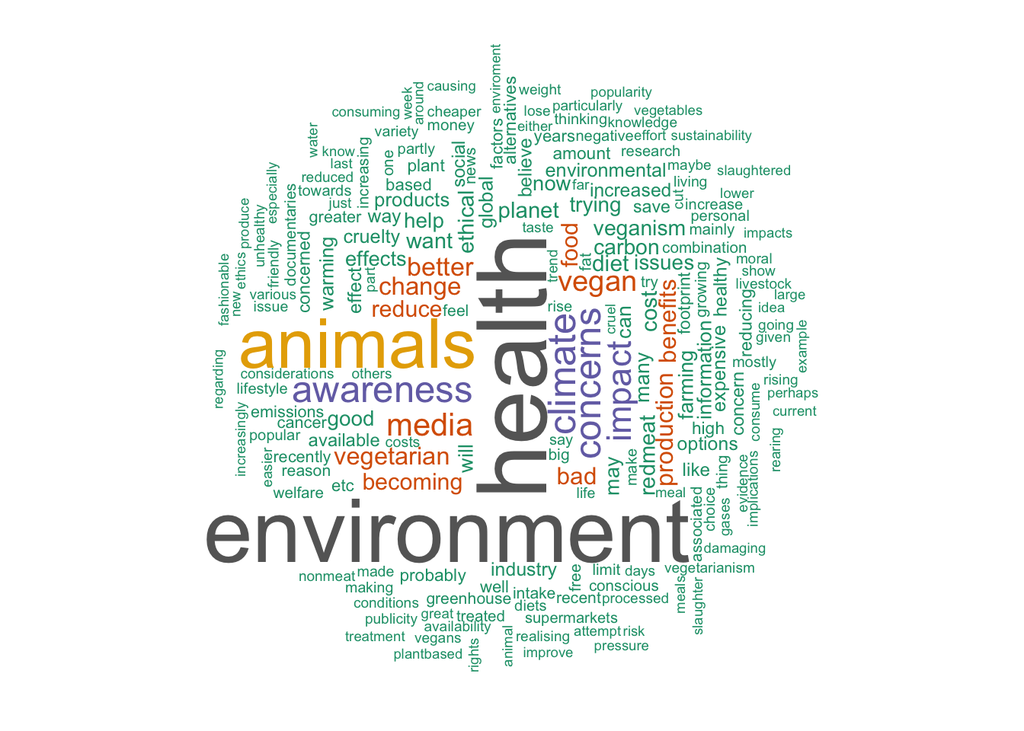

Figure 2.1: World cloud of participants response to text

Table 2.1:

*Most frequent words in text*

| word | freq |
| --- | --- |
| health | 216.00 |
| environment | 193.00 |
| animals | 144.00 |
| climate | 67.00 |
| awareness | 64.00 |
| concerns | 64.00 |
| impact | 56.00 |
| media | 50.00 |
| vegan | 43.00 |
| better | 35.00 |
| change | 33.00 |
| vegetarian | 32.00 |
| production | 31.00 |
| bad | 30.00 |
| benefits | 30.00 |
| becoming | 28.00 |
| food | 28.00 |
| reduce | 28.00 |
| diet | 27.00 |
| cost | 26.00 |

The mean interest for participants in the dynamic norm condition was *M* = 3.64 (*SD* = 1.83), and the mean interest in the static norm condition was *M* = 3.68 (*SD* = 1.84). The mean interest in the no norm condition was *M* = 3.41 (*SD* = 1.77).

There was no difference in interest in reducing meat consumption between the dynamic norm (*M* = 3.64, *SD* = 1.83) and static norm (*M* = 3.68, *SD* = 1.84) conditions, $\Delta M = -0.03$, 95% CI $[-0.34$, $0.27]$, $t(843) = -0.23$, $p = .821$, *d* = -0.02, $B_{\text{HN}(0, 0.69)}$ = 0.18, RR[0.65, 2].

Participants in the no-norm control condition showed the least interest in reducing meat consumption (*M* = 3.41, *SD* = 1.77) and did not differ from those in the dynamic-norm condition $\Delta M = 0.23$, 95% CI $[-0.07$, $0.53]$, $t(843) = 1.52$, $p = .130$, *d* = 0.13, or the static-norm condition $\Delta M = 0.27$, 95% CI $[-0.03$, $0.57]$, $t(843) = 1.76$, $p = .080$, *d* = 0.15. There was also no difference between the dynamic-norm condition and a combination of the control and static-norm conditions $\Delta M = 0.10$, 95% CI $[-0.16$, $0.36]$, $t(843) = 0.74$, $p = .458$.

Table 2.2:

*Meat consumption by condition contrasts*

|  | contrast | $\Delta M$ | 95% CI | $t(843)$ | $p$ |
| --- | --- | --- | --- | --- | --- |
| DYST | Dynamic, static | -0.03 | $[-0.34$, $0.27]$ | -0.23 | .821 |
| DYNO | Dynamic, control | 0.23 | $[-0.07$, $0.53]$ | 1.52 | .130 |
| STNO | Static, control | 0.27 | $[-0.03$, $0.57]$ | 1.76 | .080 |
| DYCONT | Dynamic, both | 0.10 | $[-0.16$, $0.36]$ | 0.74 | .458 |
| EXPNO | Norms, control | -0.25 | $[-0.51$, $0.01]$ | -1.89 | .059 |

### 2.1.2 Effect of demographic variables and condition on interest

Political left-wing participants were more interested than were right wing participants, $t(844) = -7.23$, $p < .001$, and women were more interested than were men, $\Delta M = -0.50$, 95% CI $[-0.75$, $-0.26]$, $t(781.22) = -4.00$, $p < .001$. When we controlled for these factors, the effect of the dynamic-norm condition (compared with that of the static-norm condition) on interest in eating less meat was $b = -0.27$, 95% CI $[-1.25$, $0.72]$, $t(553) = -0.53$, $p = .594$.

Table 2.3:

*Regression coefficients of demographic variables on interest*

| predictor | $b$ | 95% CI | $t(553)$ | $p$ |
| --- | --- | --- | --- | --- |
| Intercept | 4.61 | $[3.90$, $5.31]$ | 12.80 | < .001 |
| Condition | -0.27 | $[-1.25$, $0.72]$ | -0.53 | .594 |
| Gender | 0.53 | $[0.10$, $0.96]$ | 2.43 | .015 |
| Political position | -0.37 | $[-0.54$, $-0.19]$ | -4.14 | < .001 |
| Condition $\times$ Gender | -0.01 | $[-0.61$, $0.59]$ | -0.03 | .976 |
| Condition $\times$ Political position | 0.09 | $[-0.15$, $0.33]$ | 0.77 | .443 |

## 2.2 2. Will participants in the dynamic norm condition be more likely (than static norm and control) to predict a future decrease in meat consumption in the UK?

I modeled H2 using a half-normal distribution with a mean of 0 and SD of *M<sub>diff</sub>* = 0.40. The plausible maximum effect was set at twice the predicted effect of *M<sub>diff</sub>* = 0.80. A Bayes factor was calculated for each test.

Table 2.4: Expectations of future meat consumption

| Condition | $n$ | Future Norm $M$ | Future Norm $SD$ | Preconformity $M$ | Preconformity $SD$ | Combined $M$ | Combined $SD$ |
| --- | --- | --- | --- | --- | --- | --- | --- |
| Dynamic | 276 | 5.26 | 0.93 | 4.35 | 1.18 | 4.81 | 0.88 |
| Static | 284 | 5.20 | 0.85 | 4.24 | 1.19 | 4.72 | 0.85 |
| No norm | 286 | 4.97 | 0.89 | 3.95 | 1.18 | 4.46 | 0.84 |

#### 2.2.0.1 **Measure of perception of change:** “In the next 5 years, I expect meat consumption in the UK to…”

There was no evidence one way or another for an effect of dynamic norm condition on expectations about future meat consumption, $\Delta M = 0.06$, 95% CI $[-0.08$, $0.21]$, $t(843) = 0.85$, $p = .397$, *d* = 0.07, $B_{\text{HN}(0, 0.40)}$ = 0.42, RR[0.05, 0.8]

Table 2.5: Perception change contrasts

|  | contrast | estimate | ci | statistic | p.value |
| --- | --- | --- | --- | --- | --- |
| DYST | Dynamic, static | 0.06 | $[-0.08$, $0.21]$ | 0.85 | .397 |
| DYNO | Dynamic, control | 0.30 | $[0.15$, $0.44]$ | 3.94 | < .001 |
| STNO | Static, control | 0.23 | $[0.09$, $0.38]$ | 3.11 | .002 |
| DYCONT | Dynamic, both | 0.18 | $[0.05$, $0.31]$ | 2.75 | .006 |
| EXPNO | Norms, control | -0.26 | $[-0.39$, $-0.14]$ | -4.08 | < .001 |

#### 2.2.0.2 **Measure of preconformity:** “In the foreseeable future, to what extent do you think that many people will make an effort to eat less meat?”

There was no evidence one way or the other for there being a difference in anticipation that many people would make an effort to reduce their meat consumption in the future between the dynamic norm (*M* = 4.35, *SD* = 1.18) and static norm (*M* = 4.24, *SD* = 1.19) conditions, $\Delta M = 0.11$, 95% CI $[-0.09$, $0.31]$, $t(843) = 1.08$, $p = .279$, *d* = 0.09, $B_{\text{HN}(0, 0.40)}$ = 0.72, RR[0.05, 1.5].

Table 2.6: Preconformity contrasts

|  | contrast | estimate | ci | statistic | p.value |
| --- | --- | --- | --- | --- | --- |
| DYST | Dynamic, static | 0.11 | $[-0.09$, $0.31]$ | 1.08 | .279 |
| DYNO | Dynamic, control | 0.40 | $[0.20$, $0.60]$ | 4.00 | < .001 |
| STNO | Static, control | 0.29 | $[0.10$, $0.49]$ | 2.94 | .003 |
| DYCONT | Dynamic, both | 0.25 | $[0.08$, $0.43]$ | 2.93 | .004 |
| EXPNO | Norms, control | -0.35 | $[-0.52$, $-0.18]$ | -4.02 | < .001 |

#### 2.2.0.3 **Combined**

There was no evidence one way or the other for there being a difference in anticipation that many people would make an effort to reduce their meat consumption in the future between the dynamic norm (*M* = 4.81, *SD* = 0.88) and static norm (*M* = 4.72, *SD* = 0.85) conditions, $\Delta M = 0.09$, 95% CI $[-0.06$, $0.23]$, $t(843) = 1.19$, $p = .235$, *d* = 0.10, $B_{\text{HN}(0, 0.40)}$ = 0.62, RR[0.05, 1.25].

Table 2.7: Combined contrasts

|  | contrast | estimate | ci | statistic | p.value |
| --- | --- | --- | --- | --- | --- |
| DYST | Dynamic, static | 0.09 | $[-0.06$, $0.23]$ | 1.19 | .235 |
| DYNO | Dynamic, control | 0.35 | $[0.21$, $0.49]$ | 4.81 | < .001 |
| STNO | Static, control | 0.26 | $[0.12$, $0.40]$ | 3.65 | < .001 |
| DYCONT | Dynamic, both | 0.22 | $[0.09$, $0.34]$ | 3.45 | .001 |
| EXPNO | Norms, control | -0.31 | $[-0.43$, $-0.18]$ | -4.89 | < .001 |

# 3 Secondary analyses

## 3.1 1. Will there be a difference in perceptions of current static norm across the dynamic and static norm conditions?

The SESOI for percentage difference is ± 5%. The SESOI for mean difference on the Likert scale is ± 0.5.

TOST results: *t*-value lower bound: 129.959 *p*-value lower bound: 0e+00 *t*-value upper bound: $-23.608$ *p*-value upper bound: $2.99\times10^{-86}$ degrees of freedom : 557.66

Equivalence bounds (raw scores): low eqbound: $-5$ high eqbound: 5

TOST confidence interval: lower bound 90% CI: 3.355 upper bound 90% CI: 3.57

NHST confidence interval: lower bound 95% CI: 3.335 upper bound 95% CI: 3.591

Equivalence Test Result: The equivalence test was significant, *t*(557.66) = $-23.608$, *p* = $2.99\times10^{-86}$, given equivalence bounds of $-5$ and 5 (on a raw scale) and an alpha of 0.05. Null Hypothesis Test Result: The null hypothesis test was significant, *t*(557.66) = 53.175, *p* = $1.51\times10^{-220}$, given an alpha of 0.05. Based on the equivalence test and the null-hypothesis test combined, we can conclude that the observed effect is statistically different from zero and statistically equivalent to zero.

### 3.1.1 2. Will there be a difference in how meat consumption is construed across the dynamic and static norm conditions?

TOST results: *t*-value lower bound: 15.086 *p*-value lower bound: $1.12\times10^{-43}$ *t*-value upper bound: $-13.542$ *p*-value upper bound: $1.25\times10^{-36}$ degrees of freedom : 557.55

Equivalence bounds (raw scores): low eqbound: $-5$ high eqbound: 5

TOST confidence interval: lower bound 90% CI: $-0.306$ upper bound 90% CI: 0.845

NHST confidence interval: lower bound 95% CI: $-0.417$ upper bound 95% CI: 0.956

Equivalence Test Result: The equivalence test was significant, *t*(557.55) = $-13.542$, *p* = $1.25\times10^{-36}$, given equivalence bounds of $-5$ and 5 (on a raw scale) and an alpha of 0.05. Null Hypothesis Test Result: The null hypothesis test was non-significant, *t*(557.55) = 0.772, *p* = .441, given an alpha of 0.05. Based on the equivalence test and the null-hypothesis test combined, we can conclude that the observed effect is statistically not different from zero and statistically equivalent to zero.

# 4 Exploratory Analyses

## 4.1 3. Does dynamic norm (versus static or no norm) information increase participants’ positive attitude, intentions, and expectations to reduce their meat consumption?

Table 4.1: Posterior results for simple model (H3)

|  | Model 1: Uninformative priors (ppp = 0.482) Mean (SD) | Model 1: Uninformative priors (ppp = 0.482) 95% PPI | Model 1: Uninformative priors (ppp = 0.482) neff | Model 1: Uninformative priors (ppp = 0.482) PSRF | Model 1: Uninformative priors (ppp = 0.482) Prior | Model 2: Informative priors (ppp = 0.456) Mean (SD) | Model 2: Informative priors (ppp = 0.456) 95% PPI | Model 2: Informative priors (ppp = 0.456) neff | Model 2: Informative priors (ppp = 0.456) PSRF | Model 2: Informative priors (ppp = 0.456) Prior | Model 3: Informative priors (ppp = 0.372) Mean (SD) | Model 3: Informative priors (ppp = 0.372) 95% PPI | Model 3: Informative priors (ppp = 0.372) neff | Model 3: Informative priors (ppp = 0.372) PSRF | Model 3: Informative priors (ppp = 0.372) Prior |
| --- | --- | --- | --- | --- | --- | --- | --- | --- | --- | --- | --- | --- | --- | --- | --- |
| Interest | 0.045 (0.158) | -0.267, 0.348 | 671.487 | 1.003 | normal(0,10) | 0.155 (0.140) | -0.112, 0.432 | 667.965 | 1.003 | normal(0.5,0.447) | 0.224 (0.131) | -0.034, 0.476 | 691.330 | 1.003 | normal(0.5, 0.316) |
| Attitude | -0.046 (0.111) | -0.264, 0.169 | 648.334 | 1.003 | normal(0,10) | 0.034 (0.100) | -0.159, 0.222 | 682.511 | 1.004 | normal(0.5,0.447) | 0.082 (0.096) | -0.11, 0.266 | 690.612 | 1 | normal(0.5, 0.316) |
| Intention/Expectation | -0.034 (0.147) | -0.336, 0.256 | 655.894 | 1.003 | normal(0,10) | 0.074 (0.133) | -0.182, 0.33 | 667.018 | 1.003 | normal(0.5,0.447) | 0.140 (0.127) | -0.108, 0.393 | 717.670 | 1.001 | normal(0.5, 0.316) |

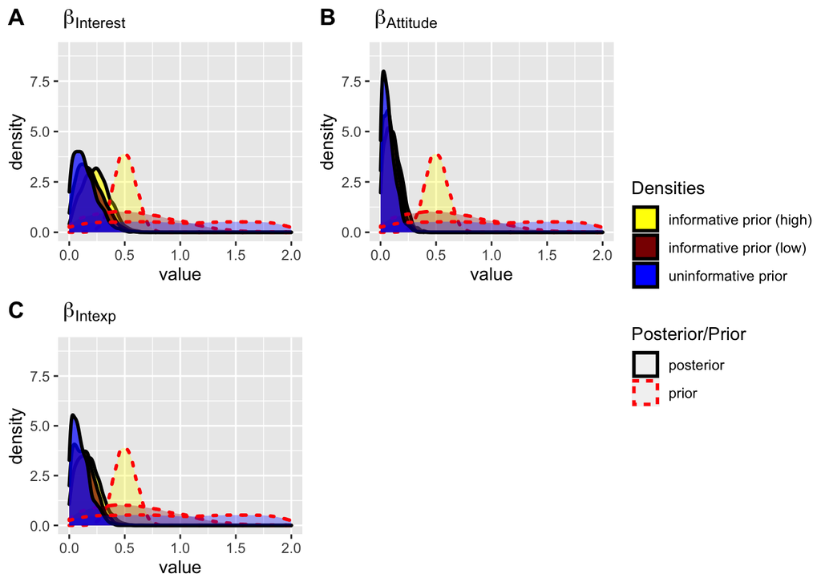

Figure 4.1: Influence of priors on posterior regression estimates

### 4.1.1 4. How do demographic factors such as age, gender, and political position predict primary dependent variables relating to meat consumption?

Table 4.2: Posterior results for full model (H4)

[output not shown]

### 4.1.2 5. How does age interact with norm condition to influence dependent variables?

Table 4.3: Posterior results for multi-sample analysis by age (H4)

| Parameter | Model 1: Uninformative priors Mean (SD) | Model 1: Uninformative priors 95% PPI | Model 1: Uninformative priors neff | Model 1: Uninformative priors PSRF | Model 1: Uninformative priors Prior | Model 2: Informative priors Mean (SD) | Model 2: Informative priors 95% PPI | Model 2: Informative priors neff | Model 2: Informative priors PSRF | Model 2: Informative priors Prior | Model 3: Informative priors Mean (SD) | Model 3: Informative priors 95% PPI | Model 3: Informative priors neff | Model 3: Informative priors PSRF | Model 3: Informative priors Prior |
| --- | --- | --- | --- | --- | --- | --- | --- | --- | --- | --- | --- | --- | --- | --- | --- |
| **Older** |  |  |  |  |  |  |  |  |  |  |  |  |  |  |  |
| Interest | 0.038 (0.216) | -0.379, 0.461 | 857.708 | 1.002 | normal(0,10) | 0.226 (0.176) | -0.121, 0.583 | 925.922 | 1.002 | normal(0.5,0.447) | 0.313 (0.162) | -0.005, 0.625 | 750.930 | 1.003 | normal(0.5,0.316) |
| Attitude | -0.077 (0.153) | -0.371, 0.233 | 856.179 | 1.002 | normal(0,10) | 0.057 (0.129) | -0.189, 0.312 | 1001.958 | 1.002 | normal(0.5,0.447) | 0.123 (0.119) | -0.121, 0.355 | 723.230 | 1.005 | normal(0.5,0.316) |
| Intention | -0.003 (0.205) | -0.389, 0.416 | 864.449 | 1.002 | normal(0,10) | 0.178 (0.171) | -0.146, 0.52 | 967.013 | 1.002 | normal(0.5,0.447) | 0.260 (0.155) | -0.042, 0.561 | 712.421 | 1.005 | normal(0.5,0.316) |
| Expectation | 0.130 (0.221) | -0.312, 0.559 | 937.224 | 1.001 | normal(0,10) | 0.297 (0.191) | -0.08, 0.668 | 682.815 | 1.004 | normal(0.5,0.447) | 0.393 (0.162) | 0.076, 0.718 | 1132.757 | 1 | normal(0.5,0.316) |
| **Younger** |  |  |  |  |  |  |  |  |  |  |  |  |  |  |  |
| Interest | 0.039 (0.158) | -0.274, 0.344 | 876.570 | 1.002 | normal(0,10) | 0.160 (0.142) | -0.108, 0.442 | 665.755 | 1.004 | normal(0.5,0.447) | 0.235 (0.126) | -0.01, 0.48 | 1068.519 | 1.001 | normal(0.5,0.316) |
| Attitude | -0.064 (0.206) | -0.47, 0.34 | 887.552 | 1.002 | normal(0,10) | 0.105 (0.182) | -0.251, 0.461 | 659.391 | 1.004 | normal(0.5,0.447) | 0.202 (0.156) | -0.099, 0.516 | 1142.422 | 1 | normal(0.5,0.316) |
| Intention | 0.038 (0.216) | -0.379, 0.461 | 857.708 | 1.002 | normal(0,10) | 0.226 (0.176) | -0.121, 0.583 | 925.922 | 1.002 | normal(0.5,0.447) | 0.313 (0.162) | -0.005, 0.625 | 750.930 | 1.003 | normal(0.5,0.316) |
| Expectation | -0.077 (0.153) | -0.371, 0.233 | 856.179 | 1.002 | normal(0,10) | 0.057 (0.129) | -0.189, 0.312 | 1001.958 | 1.002 | normal(0.5,0.447) | 0.123 (0.119) | -0.121, 0.355 | 723.230 | 1.005 | normal(0.5,0.316) |

[output not shown]